# Possible factors that affect aiming speed

## Aim speed throughout the day

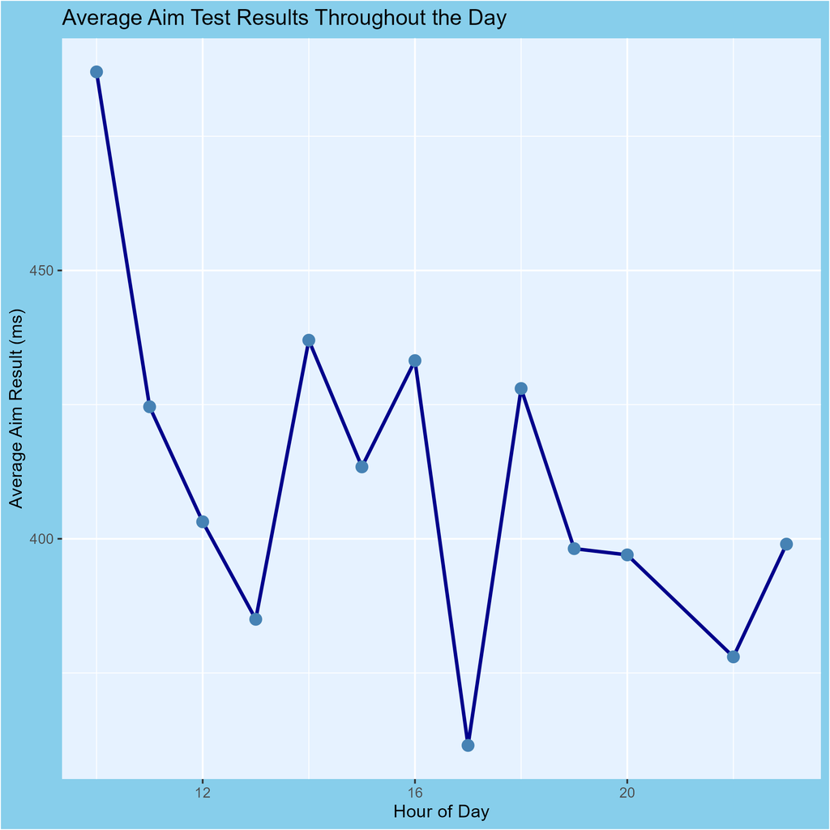

This visualization shows the relationship between aim speed in milliseconds (ms) and the time of day in more depth by using {lubridate} to get the specific hours of the day where I had filled out the form. The data suggests that aim speed varied depending on the hour the data was recorded. Earlier hours in the day generally had higher scores. Average aim times then appeared to improve around midday and later in the evening, where lower values were recorded. There are a few extreme points one in the morning at approximately 10 am where I was very slow to complete the test. This could be because I was at uni and using the track pad of my laptop. There us also an incredibly low recorded time at approximately 5 pm which could have been because there are not many values recorded at 5pm so the average is much lower than the other times.